# Atelier 10 : Exploration des données de l’EDS avec {ggplot2}

The GRAPH Courses

2024-03-20

# Chargement des packages nécessaires

```r
pacman::p_load(
  janitor,    # pour les utilitaires d'analyse de données
  here,       # pour définir le répertoire de travail
  haven,      # pour lire les fichiers Stata
  tidyverse   # pour la manipulation et la visualisation des données
)
```

*REMARQUE : Veuillez lire et exécuter le code dans l’Rmd de démonstration **AVANT** de commencer cet exercice.*

# Importation et nettoyage des données

## Étape 1 : Choisissez et importez des colonnes sélectionnées

Le bloc de code ci-dessous importe les mêmes variables que présentées dans la démo. Cependant, nous voulons augmenter cela en ajoutant cinq variables liées aux connaissances sur le paludisme.

Parcourez le fichier du dictionnaire de données et déterminez quelles cinq variables correspondent aux énoncés d’accord suivants :

- Le paludisme peut être complètement guéri par des médicaments
- Le paludisme peut entraîner la mort
- Pas de souci concernant le paludisme en raison d’un traitement facile
- Connaître des personnes malades du paludisme
- Seuls les enfants faibles peuvent mourir du paludisme

Ensuite, incorporez ces variables dans le code d’importation des données ci-dessous.

**INDICE :** Ces variables se trouvent aux pages 225-226 du fichier PDF du dictionnaire de données.

**REMARQUE :** Assurez-vous que **TOUTES les lettres** dans les noms des variables sont en minuscules. Par exemple, si le dictionnaire de données dit “S1108BA”, vous devez changer les 3 lettres en minuscules comme ceci : “s1108ba” lorsque vous l’entrez dans `col_select`.

```r
# Importer le fichier .dta et ajouter les 5 variables de connaissances sur le paludisme
ir_brut <-
  haven::read_dta(here("data/NGIR7BFL_mini.DTA"),
                  col_select = c(
                    # Informations de base
                    v006, v007, v009, v010, v012, v013,
                    v024, v025, v106, v130, v190,

                    # Littératie et médias
                    v155, v156, v157, v158, v159,

                    # Fécondité et calendrier de reproduction
                    v201, v212, v213, v511, v531,

                    # Ajouter les variables de connaissances sur le paludisme identifiées ci-dessous
                    s1108ai, s1108ba, s1108bc, s1108bd, s1108bf
                    ))
```

## Étape 2 : Attribuez des noms de variables

Attribuez des noms descriptifs aux variables nouvellement importées, puis exécutez le code ci-dessous.

```r
# Renommer les variables de connaissances sur le paludisme
ir_renomme <-
  ir_brut %>%
  rename(age = v012,
         groupe_age = v013,
         region = v024,
         urbain_rural = v025,
         niveau_education = v106,
         religion = v130,
         alphabétisation = v155,
         indice_richesse = v190,
         nb_enfants = v201,
         age_premiere_naissance = v212,
         age_premiere_coexistence = v511,
         age_premier_rapport_sexuel = v531,
         # Renommer les variables de connaissances sur le paludisme
         guerison_complete = s1108ai,
         conduit_a_mort = s1108ba,
         pas_de_soucis = s1108bc,
         connaitre_malades = s1108bd,
         enfants_faibles = s1108bf
         )
```

## Étape 3 : Révéler les valeurs codées

Avec la fonction appropriée du package `{haven}`, transformez toutes les variables en facteurs R réguliers.

```r
# Ajouter la fonction pour convertir des données étiquetées en facteurs réguliers
ir_propre <-
  ir_renomme %>%
  haven::as_factor()
```

**POINT DE CONTRÔLE** : Vous devriez maintenant avoir 3 data frames dans votre Environnement : `ir_brut`, `ir_renomme`, et `ir_propre`. Explorez l’ensemble de données `ir_propre` et assurez-vous que les modifications des étapes 1 à 3 ont été mises en œuvre avec succès. Les types de valeurs doivent être convertis en facteurs et les colonnes doivent avoir des noms significatifs. À partir de là, l’ensemble de données `ir_propre` est maintenant prêt à être utilisé et prêt pour le traçage !

# Visualisation des données

## Définir un thème global

Choisissez votre thème `{ggplot2}` préféré et écrivez le code pour l’appliquer automatiquement à tous vos graphiques.

```r
# Changer le thème par défaut
theme_set(theme_classic())
```

## Histogrammes et boîtes à moustaches pour les distributions continues

1. Choisissez l’une des variables continues de l’ensemble de données, telles que `age` ou `age_premiere_naissance`. Ensuite, générez un histogramme simple de cette variable. Assurez-vous de fournir le titre, les étiquettes, etc. nécessaires pour mieux communiquer les informations au public.

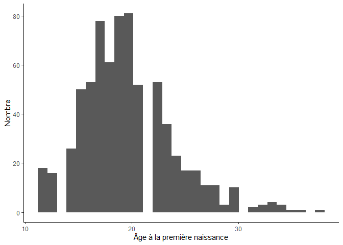

```r
# Histogramme simple
ggplot(data = ir_propre,
       mapping = aes(x = age_premiere_naissance)) +
  geom_histogram() +
  labs(x = 'Âge à la première naissance', y = 'Nombre')
```

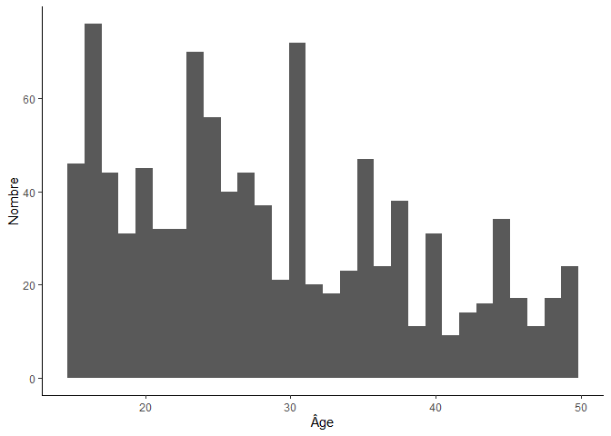

```r
ggplot(data = ir_propre,
       mapping = aes(x = age)) +
  geom_histogram() +
  labs(x = 'Âge', y = 'Nombre')
```

2. Maintenant, créez une boîte à moustaches pour montrer la distribution de la variable continue que vous avez choisie précédemment. La distribution doit être regroupée par l’une des variables liées aux connaissances sur le paludisme. Incorporez l’esthétique `fill` pour colorer les boîtes. Ajustez également les couleurs, les étiquettes, les titres, les thèmes, etc. à votre convenance.

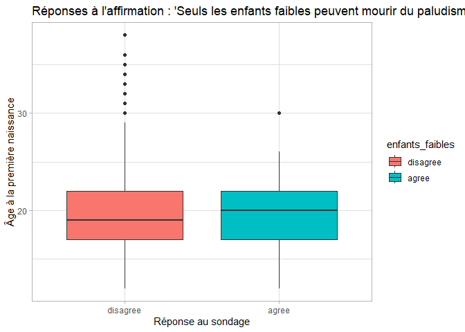

```r
# Boîte à moustaches comparant les groupes
ggplot(data = ir_propre,
       mapping = aes(x = enfants_faibles,
         y = age_premiere_naissance,
         fill = enfants_faibles)) +
  geom_boxplot() +
  labs(x = 'Réponse au sondage',
       y = 'Âge à la première naissance',
       title = "Réponses à l'affirmation : 'Seuls les enfants faibles peuvent mourir du paludisme'") +
  theme_light()
```

## Diagrammes à barres pour les distributions discrètes

1. Sélectionnez l’une des variables catégorielles de l’ensemble de données. Poursuivez en générant un simple diagramme à barres pour afficher la distribution de cette variable.

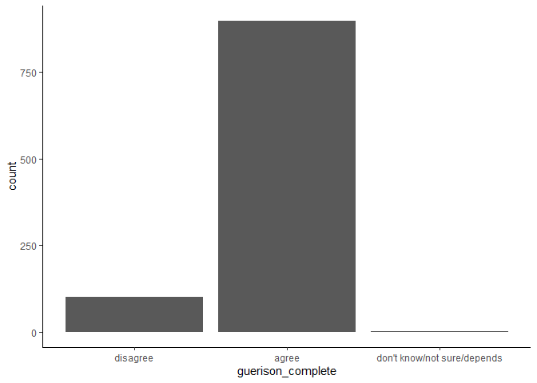

```r
# Diagramme à barres simple
ggplot(data = ir_propre,
       mapping = aes(x = guerison_complete)) +
  geom_bar()
```

2. Ensuite, adaptez votre graphique ci-dessus pour créer un diagramme à barres empilées en pourcentage. Pour ce faire, ajoutez l’esthétique `fill` et définissez-la sur une variable de connaissances sur le paludisme de votre choix ; par exemple : `aes(fill = VAR_PALUDISME)`. N’oubliez pas d’ajouter l’argument `position` approprié. Le graphique final devrait comparer comment les réponses à la question de l’enquête sur les connaissances sur le paludisme varient entre les groupes.

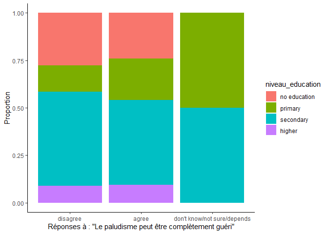

```r
# Diagramme à barres empilées en pourcentage
ggplot(data = ir_propre,
       mapping = aes(x = guerison_complete,
                     fill = niveau_education)) +
  geom_bar(position = 'fill') +
  labs(x = 'Réponses à : "Le paludisme peut être complètement guéri"',
    y = 'Proportion')
```

3. Enfin, créez un diagramme à barres GROUPÉ avec deux variables catégorielles de votre choix. Ajustez les couleurs, les étiquettes, les titres, les thèmes, etc. comme bon vous semble.

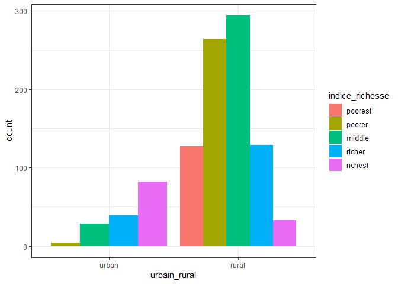

```r
# Diagramme à barres groupé
ggplot(data = ir_propre,
  mapping = aes(
    x = urbain_rural,
    fill = indice_richesse)) +
  geom_bar(position = "dodge") +
  theme_bw()
```

# Défi bonus : Diagrammes en donut

Représentez les données de votre diagramme à barres groupé sous forme de séries de diagrammes en donut.

INDICE : La fonction `facet_wrap()` de `{ggplot2}` sera utile.